```python
%pylab inline
import pandas as pd
import numpy as np
import seaborn as sns
import mpu
```

# Data preparation

```python
path='/Users/xinyao/Desktop/'
```

```python
data2018=pd.read_csv(path+'metro-bike-share-trip-data.csv')
```

## Data preview

```python
# Get attribute names
print('Attributes:',data2018.columns)
# Get dataframe shape
print('Dataframe Shape:',data2018.shape)
# Get column data types
column_meta=[]
for x in data2018.columns:
    column_meta.append((x,type(data2018[x][0])))
```

```
Attributes: Index(['Trip ID', 'Duration', 'Start Time', 'End Time', 'Starting Station ID',
       'Starting Station Latitude', 'Starting Station Longitude',
       'Ending Station ID', 'Ending Station Latitude',
       'Ending Station Longitude', 'Bike ID', 'Plan Duration',
       'Trip Route Category', 'Passholder Type', 'Starting Lat-Long',
       'Ending Lat-Long'],
      dtype='object')
Dataframe Shape: (132427, 16)
```

```python
#Preview the dataframe
data2018.head(5)
```

|  | Trip ID | Duration | Start Time | End Time | Starting Station ID | Starting Station Latitude | Starting Station Longitude | Ending Station ID | Ending Station Latitude | Ending Station Longitude | Bike ID | Plan Duration | Trip Route Category | Passholder Type | Starting Lat-Long | Ending Lat-Long |
| --- | --- | --- | --- | --- | --- | --- | --- | --- | --- | --- | --- | --- | --- | --- | --- | --- |
| 0 | 1912818 | 180 | 2016-07-07T04:17:00 | 2016-07-07T04:20:00 | 3014.0 | 34.056610 | -118.23721 | 3014.0 | 34.056610 | -118.23721 | 6281.0 | 30.0 | Round Trip | Monthly Pass | {'longitude': '-118.23721', 'latitude': '34.05... | {'longitude': '-118.23721', 'latitude': '34.05... |
| 1 | 1919661 | 1980 | 2016-07-07T06:00:00 | 2016-07-07T06:33:00 | 3014.0 | 34.056610 | -118.23721 | 3014.0 | 34.056610 | -118.23721 | 6281.0 | 30.0 | Round Trip | Monthly Pass | {'longitude': '-118.23721', 'latitude': '34.05... | {'longitude': '-118.23721', 'latitude': '34.05... |
| 2 | 1933383 | 300 | 2016-07-07T10:32:00 | 2016-07-07T10:37:00 | 3016.0 | 34.052898 | -118.24156 | 3016.0 | 34.052898 | -118.24156 | 5861.0 | 365.0 | Round Trip | Flex Pass | {'longitude': '-118.24156', 'latitude': '34.05... | {'longitude': '-118.24156', 'latitude': '34.05... |
| 3 | 1944197 | 10860 | 2016-07-07T10:37:00 | 2016-07-07T13:38:00 | 3016.0 | 34.052898 | -118.24156 | 3016.0 | 34.052898 | -118.24156 | 5861.0 | 365.0 | Round Trip | Flex Pass | {'longitude': '-118.24156', 'latitude': '34.05... | {'longitude': '-118.24156', 'latitude': '34.05... |
| 4 | 1940317 | 420 | 2016-07-07T12:51:00 | 2016-07-07T12:58:00 | 3032.0 | 34.049889 | -118.25588 | 3032.0 | 34.049889 | -118.25588 | 6674.0 | 0.0 | Round Trip | Walk-up | {'longitude': '-118.25588', 'latitude': '34.04... | {'longitude': '-118.25588', 'latitude': '34.04... |

```python
# Check for duplicate rows
len(data2018['Trip ID'].unique()) ==len(data2018)
```

```
True
```

There are no duplicate trips.

```python
# check and count null values in each column
data2018.isnull().sum()
```

```
Trip ID                           0
Duration                          0
Start Time                        0
End Time                          0
Starting Station ID              19
Starting Station Latitude        48
Starting Station Longitude       48
Ending Station ID                96
Ending Station Latitude        1051
Ending Station Longitude       1051
Bike ID                          10
Plan Duration                   766
Trip Route Category               0
Passholder Type                   0
Starting Lat-Long             33805
Ending Lat-Long                1051
dtype: int64
```

We can find that the starting station ID, starting station latitude and longtitude, starting Lat-Long. All these four columns provide the geography info on which they can support each other when some values are missing.

### Fill in the missing value

```python
#Take a look at missing starting station ID
data2018[data2018['Starting Station ID'].isnull()]
```

|  | Trip ID | Duration | Start Time | End Time | Starting Station ID | Starting Station Latitude | Starting Station Longitude | Ending Station ID | Ending Station Latitude | Ending Station Longitude | Bike ID | Plan Duration | Trip Route Category | Passholder Type | Starting Lat-Long | Ending Lat-Long |
| --- | --- | --- | --- | --- | --- | --- | --- | --- | --- | --- | --- | --- | --- | --- | --- | --- |
| 60485 | 9378284 | 60 | 2016-10-09T09:40:00 | 2016-10-09T09:41:00 | NaN | NaN | NaN | NaN | NaN | NaN | 6437.0 | NaN | One Way | Staff Annual | NaN | NaN |
| 60568 | 9399178 | 780 | 2016-10-09T12:57:00 | 2016-10-09T13:10:00 | NaN | NaN | NaN | 3036.0 | 34.039188 | -118.232529 | 6084.0 | 30.0 | One Way | Monthly Pass | NaN | {'longitude': '-118.232529', 'latitude': '34.0... |
| 60576 | 9399168 | 1920 | 2016-10-09T13:27:00 | 2016-10-09T13:59:00 | NaN | NaN | NaN | 3064.0 | 34.046810 | -118.256981 | 6437.0 | 30.0 | One Way | Monthly Pass | NaN | {'longitude': '-118.256981', 'latitude': '34.0... |
| 60581 | 9399161 | 720 | 2016-10-09T13:29:00 | 2016-10-09T13:41:00 | NaN | NaN | NaN | 3076.0 | 34.040600 | -118.253838 | 6167.0 | 30.0 | One Way | Monthly Pass | NaN | {'longitude': '-118.253838', 'latitude': '34.0... |
| 60624 | 9404478 | 1020 | 2016-10-09T14:30:00 | 2016-10-09T14:47:00 | NaN | NaN | NaN | 3030.0 | 34.051941 | -118.243530 | 6626.0 | 30.0 | One Way | Monthly Pass | NaN | {'longitude': '-118.24353', 'latitude': '34.05... |
| 60631 | 9518671 | 77160 | 2016-10-09T14:37:00 | 2016-10-10T12:03:00 | NaN | NaN | NaN | 3000.0 | NaN | NaN | 6603.0 | 30.0 | One Way | Monthly Pass | NaN | NaN |
| 69217 | 11092989 | 780 | 2016-10-23T13:34:00 | 2016-10-23T13:47:00 | NaN | NaN | NaN | 3022.0 | 34.046070 | -118.233093 | 5958.0 | 30.0 | One Way | Monthly Pass | NaN | {'longitude': '-118.233093', 'latitude': '34.0... |
| 69266 | 11097271 | 420 | 2016-10-23T14:39:00 | 2016-10-23T14:46:00 | NaN | NaN | NaN | 3058.0 | 34.035801 | -118.233170 | 5914.0 | 30.0 | One Way | Monthly Pass | NaN | {'longitude': '-118.23317', 'latitude': '34.03... |
| 69329 | 11106001 | 840 | 2016-10-23T16:24:00 | 2016-10-23T16:38:00 | NaN | NaN | NaN | 3022.0 | 34.046070 | -118.233093 | 6008.0 | 365.0 | One Way | Flex Pass | NaN | {'longitude': '-118.233093', 'latitude': '34.0... |
| 76770 | 12526688 | 1320 | 2016-11-06T13:36:00 | 2016-11-06T13:58:00 | NaN | NaN | NaN | 3014.0 | 34.056610 | -118.237213 | 6076.0 | 30.0 | One Way | Monthly Pass | NaN | {'longitude': '-118.237213', 'latitude': '34.0... |
| 76826 | 12531532 | 1500 | 2016-11-06T14:34:00 | 2016-11-06T14:59:00 | NaN | NaN | NaN | 3034.0 | 34.042061 | -118.263382 | 5997.0 | 30.0 | One Way | Monthly Pass | NaN | {'longitude': '-118.263382', 'latitude': '34.0... |
| 76827 | 12531529 | 1440 | 2016-11-06T14:35:00 | 2016-11-06T14:59:00 | NaN | NaN | NaN | 3034.0 | 34.042061 | -118.263382 | 6032.0 | 30.0 | One Way | Monthly Pass | NaN | {'longitude': '-118.263382', 'latitude': '34.0... |
| 76901 | 12541451 | 660 | 2016-11-06T15:59:00 | 2016-11-06T16:10:00 | NaN | NaN | NaN | 3029.0 | 34.048851 | -118.246422 | 6376.0 | 365.0 | One Way | Flex Pass | NaN | {'longitude': '-118.246422', 'latitude': '34.0... |
| 92316 | 15697534 | 600 | 2016-12-11T11:03:00 | 2016-12-11T11:13:00 | NaN | NaN | NaN | 3067.0 | 34.045181 | -118.250237 | 6611.0 | 365.0 | One Way | Flex Pass | NaN | {'longitude': '-118.250237', 'latitude': '34.0... |
| 92409 | 15708679 | 840 | 2016-12-11T14:43:00 | 2016-12-11T14:57:00 | NaN | NaN | NaN | 3055.0 | 34.044159 | -118.251579 | 6183.0 | 30.0 | One Way | Monthly Pass | NaN | {'longitude': '-118.251579', 'latitude': '34.0... |
| 92438 | 15712463 | 1140 | 2016-12-11T15:25:00 | 2016-12-11T15:44:00 | NaN | NaN | NaN | 3034.0 | 34.042061 | -118.263382 | 6644.0 | 30.0 | One Way | Monthly Pass | NaN | {'longitude': '-118.263382', 'latitude': '34.0... |
| 92439 | 15712462 | 1020 | 2016-12-11T15:27:00 | 2016-12-11T15:44:00 | NaN | NaN | NaN | 3034.0 | 34.042061 | -118.263382 | 6135.0 | 30.0 | One Way | Monthly Pass | NaN | {'longitude': '-118.263382', 'latitude': '34.0... |
| 95231 | 16332231 | 900 | 2016-12-19T17:07:00 | 2016-12-19T17:22:00 | NaN | NaN | NaN | 3062.0 | 34.047749 | -118.243172 | 6479.0 | NaN | One Way | Staff Annual | NaN | {'longitude': '-118.243172', 'latitude': '34.0... |
| 97648 | 16871815 | 1200 | 2016-12-28T13:02:00 | 2016-12-28T13:22:00 | NaN | NaN | NaN | NaN | NaN | NaN | 6658.0 | NaN | One Way | Staff Annual | NaN | NaN |

Since for all the missing Station ID row, the longitude and latitude info are also missing, we can't fill in the missing values properly. Instead, we choose to delete them.

```python
data2019=data2018[data2018['Starting Station ID'].isnull()!=True]
```

```python
#Take the same steps for missing ending station ID
data2020=data2019[data2019['Ending Station ID'].isnull()!=True]
```

Now we need to fill missing starting/ending station Latitude and Longitude according to Starting/Ending Station ID, Plan Duration according to Passholder Type.

```python
#Take a look at Latitude for differetn station ID
data2020.groupby("Starting Station ID")["Starting Station Latitude"].mean().head()
```

```
Starting Station ID
3000.0          NaN
3005.0    34.048550
3006.0    34.045540
3007.0    34.050480
3008.0    34.046612
Name: Starting Station Latitude, dtype: float64
```

```python
data2020[data2020['Starting Station Latitude'].isnull()]
```

|  | Trip ID | Duration | Start Time | End Time | Starting Station ID | Starting Station Latitude | Starting Station Longitude | Ending Station ID | Ending Station Latitude | Ending Station Longitude | Bike ID | Plan Duration | Trip Route Category | Passholder Type | Starting Lat-Long | Ending Lat-Long |
| --- | --- | --- | --- | --- | --- | --- | --- | --- | --- | --- | --- | --- | --- | --- | --- | --- |
| 103005 | 17950743 | 660 | 2017-01-15T13:40:00 | 2017-01-15T13:51:00 | 3000.0 | NaN | NaN | 3058.0 | 34.035801 | -118.233170 | 5987.0 | 30.0 | One Way | Monthly Pass | NaN | {'longitude': '-118.23317', 'latitude': '34.03... |
| 114734 | 20310927 | 1560 | 2017-02-18T15:54:00 | 2017-02-18T16:20:00 | 3000.0 | NaN | NaN | 3069.0 | 34.050880 | -118.248253 | 6622.0 | NaN | One Way | Monthly Pass | NaN | {'longitude': '-118.248253', 'latitude': '34.0... |
| 117493 | 20813352 | 2100 | 2017-02-26T11:31:00 | 2017-02-26T12:06:00 | 3000.0 | NaN | NaN | 3067.0 | 34.045181 | -118.250237 | 6298.0 | 365.0 | One Way | Flex Pass | NaN | {'longitude': '-118.250237', 'latitude': '34.0... |
| 117549 | 20819605 | 1320 | 2017-02-26T13:40:00 | 2017-02-26T14:02:00 | 3000.0 | NaN | NaN | 3076.0 | 34.040600 | -118.253838 | 6548.0 | 30.0 | One Way | Monthly Pass | NaN | {'longitude': '-118.253838', 'latitude': '34.0... |
| 117605 | 20825981 | 1740 | 2017-02-26T15:40:00 | 2017-02-26T16:09:00 | 3000.0 | NaN | NaN | 3049.0 | 34.056969 | -118.253593 | 6179.0 | 30.0 | One Way | Monthly Pass | NaN | {'longitude': '-118.253593', 'latitude': '34.0... |
| 117639 | 20829213 | 1080 | 2017-02-26T17:06:00 | 2017-02-26T17:24:00 | 3000.0 | NaN | NaN | 3006.0 | 34.045540 | -118.256668 | 6398.0 | NaN | One Way | Monthly Pass | NaN | {'longitude': '-118.256668', 'latitude': '34.0... |
| 117984 | 20904925 | 720 | 2017-02-27T16:54:00 | 2017-02-27T17:06:00 | 3000.0 | NaN | NaN | 3062.0 | 34.047749 | -118.243172 | 5975.0 | NaN | One Way | Monthly Pass | NaN | {'longitude': '-118.243172', 'latitude': '34.0... |
| 118937 | 21101030 | 2160 | 2017-03-02T07:16:00 | 2017-03-02T07:52:00 | 3000.0 | NaN | NaN | 3035.0 | 34.048401 | -118.260948 | 5971.0 | NaN | One Way | Monthly Pass | NaN | {'longitude': '-118.260948', 'latitude': '34.0... |
| 120538 | 21415209 | 780 | 2017-03-06T08:13:00 | 2017-03-06T08:26:00 | 3000.0 | NaN | NaN | 3075.0 | 34.042110 | -118.256187 | 6205.0 | NaN | One Way | Monthly Pass | NaN | {'longitude': '-118.256187', 'latitude': '34.0... |
| 122090 | 21688313 | 1320 | 2017-03-09T17:55:00 | 2017-03-09T18:17:00 | 3000.0 | NaN | NaN | 3052.0 | 34.051102 | -118.264557 | 5902.0 | NaN | One Way | Monthly Pass | NaN | {'longitude': '-118.264557', 'latitude': '34.0... |
| 122423 | 21750457 | 720 | 2017-03-10T12:41:00 | 2017-03-10T12:53:00 | 3000.0 | NaN | NaN | 3014.0 | 34.056610 | -118.237213 | 5865.0 | NaN | One Way | Monthly Pass | NaN | {'longitude': '-118.237213', 'latitude': '34.0... |
| 122729 | 21784504 | 1200 | 2017-03-10T21:23:00 | 2017-03-10T21:43:00 | 3000.0 | NaN | NaN | 3052.0 | 34.051102 | -118.264557 | 5971.0 | NaN | One Way | Monthly Pass | NaN | {'longitude': '-118.264557', 'latitude': '34.0... |
| 123308 | 21926437 | 1380 | 2017-03-12T12:29:00 | 2017-03-12T12:52:00 | 3000.0 | NaN | NaN | 3082.0 | 34.046520 | -118.237411 | 6110.0 | 30.0 | One Way | Monthly Pass | NaN | {'longitude': '-118.237411', 'latitude': '34.0... |
| 123379 | 21934003 | 780 | 2017-03-12T14:44:00 | 2017-03-12T14:57:00 | 3000.0 | NaN | NaN | 3064.0 | 34.046810 | -118.256981 | 6466.0 | 30.0 | One Way | Monthly Pass | NaN | {'longitude': '-118.256981', 'latitude': '34.0... |
| 123380 | 21934002 | 720 | 2017-03-12T14:45:00 | 2017-03-12T14:57:00 | 3000.0 | NaN | NaN | 3064.0 | 34.046810 | -118.256981 | 6205.0 | 30.0 | One Way | Monthly Pass | NaN | {'longitude': '-118.256981', 'latitude': '34.0... |
| 124191 | 22098031 | 1020 | 2017-03-14T09:41:00 | 2017-03-14T09:58:00 | 3000.0 | NaN | NaN | 3014.0 | 34.056610 | -118.237213 | 6619.0 | NaN | One Way | Monthly Pass | NaN | {'longitude': '-118.237213', 'latitude': '34.0... |
| 126669 | 22591306 | 2940 | 2017-03-19T14:14:00 | 2017-03-19T15:03:00 | 3000.0 | NaN | NaN | 3069.0 | 34.050880 | -118.248253 | 6603.0 | 365.0 | One Way | Flex Pass | NaN | {'longitude': '-118.248253', 'latitude': '34.0... |
| 126673 | 22591302 | 2700 | 2017-03-19T14:18:00 | 2017-03-19T15:03:00 | 3000.0 | NaN | NaN | 3069.0 | 34.050880 | -118.248253 | 6641.0 | 365.0 | One Way | Flex Pass | NaN | {'longitude': '-118.248253', 'latitude': '34.0... |
| 126753 | 22595253 | 900 | 2017-03-19T15:46:00 | 2017-03-19T16:01:00 | 3000.0 | NaN | NaN | 3058.0 | 34.035801 | -118.233170 | 6260.0 | 30.0 | One Way | Monthly Pass | NaN | {'longitude': '-118.23317', 'latitude': '34.03... |
| 126759 | 22595248 | 540 | 2017-03-19T15:52:00 | 2017-03-19T16:01:00 | 3000.0 | NaN | NaN | 3058.0 | 34.035801 | -118.233170 | 6677.0 | 30.0 | One Way | Monthly Pass | NaN | {'longitude': '-118.23317', 'latitude': '34.03... |
| 126770 | 22599308 | 4140 | 2017-03-19T16:10:00 | 2017-03-19T17:19:00 | 3000.0 | NaN | NaN | 3082.0 | 34.046520 | -118.237411 | 5744.0 | 30.0 | One Way | Monthly Pass | NaN | {'longitude': '-118.237411', 'latitude': '34.0... |
| 126772 | 22705760 | 86400 | 2017-03-19T16:12:00 | 2017-03-20T20:02:00 | 3000.0 | NaN | NaN | 3000.0 | NaN | NaN | 6411.0 | 30.0 | One Way | Monthly Pass | NaN | NaN |
| 127218 | 22692514 | 2160 | 2017-03-20T17:07:00 | 2017-03-20T17:43:00 | 3000.0 | NaN | NaN | 3052.0 | 34.051102 | -118.264557 | 4728.0 | NaN | One Way | Monthly Pass | NaN | {'longitude': '-118.264557', 'latitude': '34.0... |
| 129637 | 23187120 | 18660 | 2017-03-26T10:37:00 | 2017-03-26T15:48:00 | 3000.0 | NaN | NaN | 3000.0 | NaN | NaN | 1349.0 | 30.0 | One Way | Monthly Pass | NaN | NaN |
| 129876 | 23198436 | 9180 | 2017-03-26T16:06:00 | 2017-03-26T18:39:00 | 3000.0 | NaN | NaN | 3055.0 | 34.044159 | -118.251579 | 5735.0 | 365.0 | One Way | Flex Pass | NaN | {'longitude': '-118.251579', 'latitude': '34.0... |
| 131068 | 23440989 | 960 | 2017-03-29T12:38:00 | 2017-03-29T12:54:00 | 3000.0 | NaN | NaN | 3030.0 | 34.051941 | -118.243530 | 5762.0 | NaN | One Way | Monthly Pass | NaN | {'longitude': '-118.24353', 'latitude': '34.05... |
| 131944 | 23607494 | 60 | 2017-03-31T08:06:00 | 2017-03-31T08:07:00 | 3000.0 | NaN | NaN | 3000.0 | NaN | NaN | 6324.0 | NaN | Round Trip | Monthly Pass | NaN | NaN |
| 131945 | 23607490 | 60 | 2017-03-31T08:08:00 | 2017-03-31T08:09:00 | 3000.0 | NaN | NaN | 3000.0 | NaN | NaN | 6678.0 | NaN | Round Trip | Monthly Pass | NaN | NaN |
| 131946 | 23607487 | 60 | 2017-03-31T08:09:00 | 2017-03-31T08:10:00 | 3000.0 | NaN | NaN | 3000.0 | NaN | NaN | 5944.0 | NaN | Round Trip | Monthly Pass | NaN | NaN |

The same way for longitude and then for Ending Station ID.

Find that Starting/Ending Station ID=3000 lack the data about longitude and latitude.

```python
#DROP STATION ID=3000
data2021=data2020[(data2020['Starting Station ID']!= 3000.0) & (data2020['Ending Station ID']!= 3000.0)]
```

```python
#DROP COLUMN"Starting Lat-Long" AND "Ending Lat-Long" since we already have lat and long columns.
data2021=data2021.drop('Starting Lat-Long',axis=1)
data2021=data2021.drop('Ending Lat-Long',axis=1)
```

```python
#fill in plan duration according to passholder type
data2021["Plan Duration"] = data2021["Plan Duration"].fillna(data2021.groupby('Passholder Type')["Plan Duration"].transform("mean"))
```

```python
data2021.groupby('Passholder Type')["Plan Duration"].mean()
```

```
Passholder Type
Flex Pass       365.0
Monthly Pass     30.0
Staff Annual      NaN
Walk-up           0.0
Name: Plan Duration, dtype: float64
```

We find that the Plan Duration for Staff Annual is NaN

```python
#Fill staff annual with "360.0"
data2021["Plan Duration"]=data2021["Plan Duration"].fillna(360.0)
```

```python
#Fill bike ID NA with 0
data2021["Bike ID"]=data2021["Bike ID"].fillna(0)
```

```python
#Check Null values
data2021.isnull().sum()
```

```
Trip ID                       0
Duration                      0
Start Time                    0
End Time                      0
Starting Station ID           0
Starting Station Latitude     0
Starting Station Longitude    0
Ending Station ID             0
Ending Station Latitude       0
Ending Station Longitude      0
Bike ID                       0
Plan Duration                 0
Trip Route Category           0
Passholder Type               0
dtype: int64
```

### By now all the columns don't have missing value

```python
#Convert Station ID, Plan Duration's datatype into int(Bike ID
```

```python
data2021['Starting Station ID']=data2021['Starting Station ID'].astype(int)
data2021['Ending Station ID']=data2021['Ending Station ID'].astype(int)
data2021["Bike ID"]=data2021["Bike ID"].astype(int)
data2021['Plan Duration']=data2021['Plan Duration'].astype(int)
```

```python
# Transform 2 columns containing time series data to clean form
data2021['Start Time'] = pd.to_datetime(data2021['Start Time'], format='%Y-%m-%dT%H:%M:%S')
data2021['End Time'] = pd.to_datetime(data2021['End Time'], format='%Y-%m-%dT%H:%M:%S')
```

```python
# reset index
data2021.set_index('Start Time', inplace=True)
```

## Data Visuals: Display or graph 3 metrics or trends from the data set that are interesting to you.

```python
#Here we can draw a pie chart shows the Proportion of diff passholder type
#this chart can also combined with time series or location
data2021['Passholder Type'].value_counts()
```

```
Monthly Pass    80823
Walk-up         40743
Flex Pass        9457
Staff Annual      313
Name: Passholder Type, dtype: int64
```

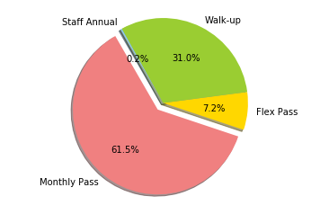

```python
import matplotlib.pyplot as plt

# Data to plot
labels = 'Monthly Pass','Flex Pass','Walk-up','Staff Annual'
sizes = [80823,9457,40743, 313]
colors = ['lightcoral','gold', 'yellowgreen','lightskyblue']
explode = (0.1, 0, 0, 0)  # explode 1st slice

# Plot
plt.pie(sizes, explode=explode, labels=labels, colors=colors,
        autopct='%1.1f%%', shadow=True, startangle=120)

plt.axis('equal')
plt.show()
```

## Which start/stop stations are most popular?

```python
#Count the most popular start/stop station for the whole dataset first.
```

```python
data2021['Ending Station ID'].value_counts().head()
```

```
3005    6262
3031    5517
3014    5382
3042    5293
3069    5069
Name: Ending Station ID, dtype: int64
```

```python
data2021['Starting Station ID'].value_counts().head()
```

```
3069    5095
3030    5038
3005    4851
3064    4617
3031    4594
Name: Starting Station ID, dtype: int64
```

## What is the average distance traveled?

```python
#Split data into one-way and roundtrip
data2021['Trip Route Category'].value_counts()
```

```
One Way       118554
Round Trip     12782
Name: Trip Route Category, dtype: int64
```

```python
data_one=data2021[data2021['Trip Route Category']=='One Way']
data_round=data2021[data2021['Trip Route Category']!='One Way']
```

```python
data_one.head()
```

| Start Time | Trip ID | Duration | End Time | Starting Station ID | Starting Station Latitude | Starting Station Longitude | Ending Station ID | Ending Station Latitude | Ending Station Longitude | Bike ID | Plan Duration | Trip Route Category | Passholder Type |
| --- | --- | --- | --- | --- | --- | --- | --- | --- | --- | --- | --- | --- | --- |
| 2016-07-07 12:51:00 | 1944075 | 780 | 2016-07-07 13:04:00 | 3021 | 34.045609 | -118.23703 | 3054 | 34.039219 | -118.23649 | 6717 | 30 | One Way | Monthly Pass |
| 2016-07-07 12:54:00 | 1944073 | 600 | 2016-07-07 13:04:00 | 3022 | 34.046070 | -118.23309 | 3014 | 34.056610 | -118.23721 | 5721 | 30 | One Way | Monthly Pass |
| 2016-07-07 12:59:00 | 1944067 | 600 | 2016-07-07 13:09:00 | 3076 | 34.040600 | -118.25384 | 3005 | 34.048550 | -118.25905 | 5957 | 365 | One Way | Flex Pass |
| 2016-07-07 13:01:00 | 1944063 | 960 | 2016-07-07 13:17:00 | 3031 | 34.044701 | -118.25244 | 3078 | 34.064281 | -118.23894 | 6351 | 30 | One Way | Monthly Pass |
| 2016-07-07 13:02:00 | 1944061 | 960 | 2016-07-07 13:18:00 | 3031 | 34.044701 | -118.25244 | 3047 | 34.039982 | -118.26640 | 6200 | 365 | One Way | Flex Pass |

```python
#Create a new column 'Distance' based on the distance between starting and ending stations.
```

```python
# Starting point
lat1 = data_one['Starting Station Latitude']
lon1 = data_one['Starting Station Longitude']

# Ending point
lat2 = data_one['Ending Station Latitude']
lon2 = data_one['Ending Station Longitude']

# Distance between two stations
# use the formula dist = mpu.haversine_distance((lat1, lon1), (lat2, lon2))
data_one['Distance']=data_one.apply(lambda row: mpu.haversine_distance((row['Starting Station Latitude'], row['Starting Station Longitude']), (row['Ending Station Latitude'],row['Ending Station Longitude'])),axis=1)

# Distance unit is km
```

```python
data_one.head()
```

[output not shown]

```python
#Create a new column 'Speed' based on the distance and duration.
data_one['Speed']=data_one.apply(lambda d: d.Distance/d.Duration,axis=1)
```

However, we find that this way of estimating speed is not good. Since people can leave the bike for some time, even over night, instead of riding it all the time. So we choose the trip where duration<1200 to gurantee that most of time people are actually riding.

```python
data_one_short=data_one[data_one.Duration<1200]
data_one_short
```

```python
#Calulate the average speed of one-way bikers.
avg_speed=data_one_short.Speed.mean()
avg_speed
```

```
0.005618115731924246
```

```python
#Calculate the total and average travel distance of one-way bikers.
t_distance=data_one.Distance.sum()
avg_distance=t_distance/data_one['Distance'].count()
print(t_distance, avg_distance,data_one['Distance'].count())
```

```
642956.2187142154 5.423319489129135 118554
```

```python
#Use the average speed of one-way bikers as the estimate of round way bikers' speed
#Create a new column 'Distance' for round trip bikers.
#data_round['Distance']=data_round.apply(lambda d: d.Duration*avg_speed,axis=1)
```

```python
data_round.head()
```

[output not shown]

However, this distance can not be accurate, because for round trip, people may stop at somewhere to shopping or visiting. We can't know how much time they actucally spent on riding bikes from current dataset.

Besides, the number of round trips is much smaller than that of one way trips. So we choose to use the average distance of one way trips to estimate the average distance traveled.

```python
avg_distance
```

```
5.423319489129135
```

## How many riders include bike sharing as a regular part of their commute?

```python
#Here we consider people who use Monthly Pass and Flex Pass as regular users.
data2021['Passholder Type'].value_counts()
```

```
Monthly Pass    80823
Walk-up         40743
Flex Pass        9457
Staff Annual      313
Name: Passholder Type, dtype: int64
```

```python
Regular_user=80823+9457
Regular_user
```

```
90280
```

## How does ridership change with seasons? Types of passes used, trip duration, etc

### Trip duration daily pattern

```
Text(0.5,0,'day of 2016-2017')
```

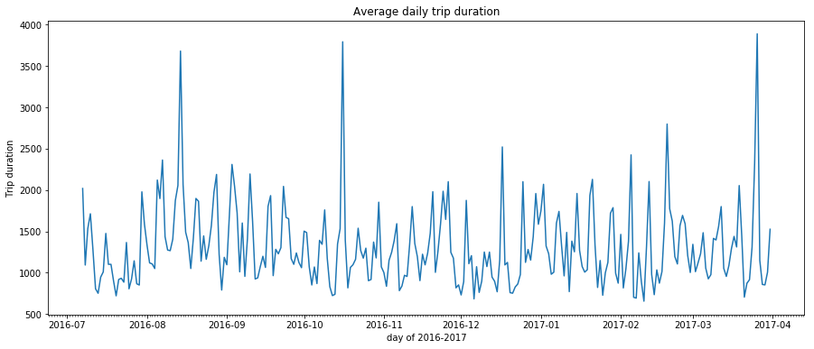

```python
# Resample to daily measurements
from matplotlib import dates
days = dates.DayLocator()

fig = plt.figure(figsize=(15,6))
ax = fig.add_subplot(111)
ax.xaxis.set_minor_locator(days)

ax.set_title('Average daily trip duration')
ax.plot(data2021['Duration'].resample('D').mean())
ax.set_ylabel('Trip duration')
ax.set_xlabel('day of 2016-2017')
```

We can't find a clear pattern of daily average duration change with time. But what should be noticed is that there are three days where duration is extremely high.

```python
#Find the highest day and second highest day in 2018

y=data2021['Duration'].resample('D').mean()
ymax = max(y)
xmax = y[y==ymax]
print(xmax,ymax)

ymax_2=max(y[y<ymax])
xmax_2=y[y==ymax_2]
print(xmax_2,ymax_2)
```

```
Start Time
2017-03-26    3888.697395
Freq: D, Name: Duration, dtype: float64 3888.697394789579
Start Time
2016-10-16    3792.186865
Freq: D, Name: Duration, dtype: float64 3792.186865267434
```

```python
#df1=data2021.loc['20170326 00':'20170326 23']
#df2=data2021.loc['20161016 00':'20161017 00']
```

```python
#data2021[data2021['Duration']==86400]
```

```
Text(0.5,0,'day of 2016-2017')
```

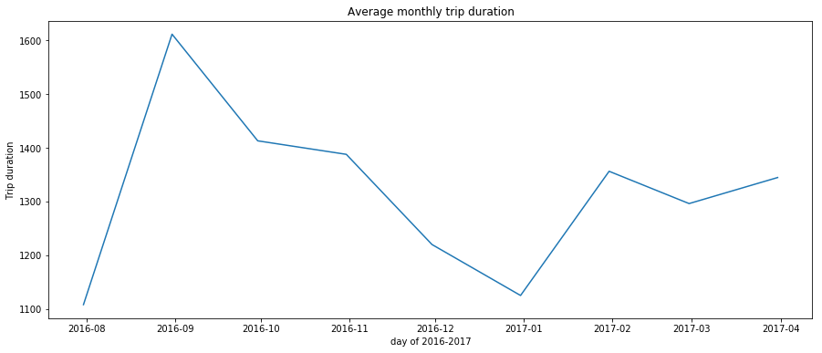

```python
# Resample to monthly measurements
from matplotlib import dates
months = dates.MonthLocator()

fig = plt.figure(figsize=(15,6))
ax = fig.add_subplot(111)

ax.xaxis.set_minor_locator(months)

ax.set_title('Average monthly trip duration')
ax.plot(data2021['Duration'].resample('M').mean())
ax.set_ylabel('Trip duration')
ax.set_xlabel('day of 2016-2017')
```

Here we can find a clear trend that the average duration time went up in August and reached highest point in September, then decreased through October to January, reaching it's lowest point at Januray. After that it rised again and kept at a medial level in March. This may because the weather in September, October is nice and natural conditions are good for cycling. But in Dec and Jan, it's somehow cold outside and people choose to ride less time on the road.

### Types of passes used

```python
data2021['Passholder Type'].value_counts()
```

```
Monthly Pass    80823
Walk-up         40743
Flex Pass        9457
Staff Annual      313
Name: Passholder Type, dtype: int64
```

```
Text(0.5,1,'Average daily number of passes')
```

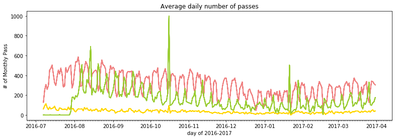

```python
#Find the season pattern of types of passes used

days = dates.DayLocator()

fig = plt.figure(figsize=(13,4))
ax = fig.add_subplot(111)

ax.xaxis.set_minor_locator(days)

ax.plot(data2021[data2021['Passholder Type']=='Monthly Pass'].resample('D').count(),color='lightcoral')

ax.plot(data2021[data2021['Passholder Type']=='Flex Pass'].resample('D').count(),color='gold')
ax.plot(data2021[data2021['Passholder Type']=='Walk-up'].resample('D').count(),color='yellowgreen')


ax.set_ylabel('# of Monthly Pass')
ax.set_xlabel('day of 2016-2017')
ax.set_title('Average daily number of passes')




#plt.plot( 'x', 'y1', data=df, marker='o', markerfacecolor='blue', markersize=12, color='skyblue', linewidth=4)
#plt.plot( 'x', 'y2', data=df, marker='', color='olive', linewidth=2)
#plt.plot( 'x', 'y3', data=df, marker='', color='olive', linewidth=2, linestyle='dashed', label="toto")
```

#### For Flex pass type, it kept relatively flat all the time.

#### For Monthly pass and Walk-up, they have some patterns!It seems that when one went down, the other went up.

```
Text(0.5,1,'Average daily number of passes')
```

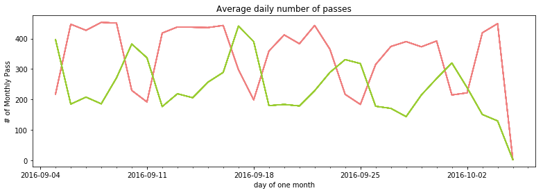

```python
#Took a look at one month's data

#2016 0905 is a Monday

df3=df.loc['20160905 00':'20161005 00']

fig = plt.figure(figsize=(13,4))
ax = fig.add_subplot(111)

ax.xaxis.set_minor_locator(days)




ax.plot(df3[df3['Passholder Type']=='Monthly Pass'].resample('D').count(),color='lightcoral')

#ax.plot(df3[df3['Passholder Type']=='Flex Pass'].resample('D').count(),color='gold')
ax.plot(df3[df3['Passholder Type']=='Walk-up'].resample('D').count(),color='yellowgreen')

ax.set_ylabel('# of Monthly Pass')
ax.set_xlabel('day of one month')
ax.set_title('Average daily number of passes')
```

### There are weekly pattern for the use of Monthly pass and walk-up!

From the plot above we can see that the numbers of passes used experienced periodly drop and rise. On weekdays, the number of monthly pass went up and kept high. At the weekend, the requests decreased quickly and reached its lowest point on Sunday. However, the number of walk-up performed in a opposite way. It went high at weekends and dropped down on weekdays.

The reason for this pattern can be guessed that people who use bike sharing as a regular part of their commute,just like the monthly pass users, will use bikes to work or study more often on weekdays. On the other side, people who don't regularly use sharing bikes, such as the walk-up users, will be more likely to use bikes during their weekends and holidays, when they go outside travelling or sightseeing.

### Is there a net change of bikes over the course of a day? If so, when and where should bikes be transported in order to make sure bikes match travel patterns?

There will surely be a net change at each station over the course of day. Because there are so many days and stations to analyze, we think it's more practical to give the recommendation monthly about transportation of bikes based on the net change of each station every month.

```python
#Convert date time to month
data2021['indext']=data2021.index
data2021['month']=data2021['index'].dt.to_period('M')
data2021.head()

#df['month_year'] = df.date_column.dt.to_period('M')
```

| Start Time | Trip ID | Duration | End Time | Starting Station ID | Starting Station Latitude | Starting Station Longitude | Ending Station ID | Ending Station Latitude | Ending Station Longitude | Bike ID | Plan Duration | Trip Route Category | Passholder Type | index | month | indext |
| --- | --- | --- | --- | --- | --- | --- | --- | --- | --- | --- | --- | --- | --- | --- | --- | --- |
| 2016-07-07 04:17:00 | 1912818 | 180 | 2016-07-07 04:20:00 | 3014 | 34.056610 | -118.23721 | 3014 | 34.056610 | -118.23721 | 6281 | 30 | Round Trip | Monthly Pass | 2016-07-07 04:17:00 | 2016-07 | 2016-07-07 04:17:00 |
| 2016-07-07 06:00:00 | 1919661 | 1980 | 2016-07-07 06:33:00 | 3014 | 34.056610 | -118.23721 | 3014 | 34.056610 | -118.23721 | 6281 | 30 | Round Trip | Monthly Pass | 2016-07-07 06:00:00 | 2016-07 | 2016-07-07 06:00:00 |
| 2016-07-07 10:32:00 | 1933383 | 300 | 2016-07-07 10:37:00 | 3016 | 34.052898 | -118.24156 | 3016 | 34.052898 | -118.24156 | 5861 | 365 | Round Trip | Flex Pass | 2016-07-07 10:32:00 | 2016-07 | 2016-07-07 10:32:00 |
| 2016-07-07 10:37:00 | 1944197 | 10860 | 2016-07-07 13:38:00 | 3016 | 34.052898 | -118.24156 | 3016 | 34.052898 | -118.24156 | 5861 | 365 | Round Trip | Flex Pass | 2016-07-07 10:37:00 | 2016-07 | 2016-07-07 10:37:00 |
| 2016-07-07 12:51:00 | 1940317 | 420 | 2016-07-07 12:58:00 | 3032 | 34.049889 | -118.25588 | 3032 | 34.049889 | -118.25588 | 6674 | 0 | Round Trip | Walk-up | 2016-07-07 12:51:00 | 2016-07 | 2016-07-07 12:51:00 |

```python
#Here is the how many bikes went out of a station each month

data_out=data2021.groupby(['month','Starting Station ID']).size()
data_out
#df.groupby(['col5', 'col2']).size()
```

```
month    Starting Station ID
2016-07  3005                   394
         3006                   369
         3007                   165
         3008                   147
         3010                    27
         3011                    78
         3014                   499
         3016                   293
         3018                   136
         3019                   226
         3020                    40
         3021                   393
         3022                   379
         3023                   113
```

[output cut: 48 more lines]

```python
#Here is the how many bikes went into of a station each month
data_in=data2021.groupby(['month','Ending Station ID']).size()

data_in

#data2021.groupby(['month','Ending Station ID']).size().reset_index().groupby('month')[[0]].max()
```

```
month    Ending Station ID
2016-07  3005                 482
         3006                 363
         3007                 140
         3008                 192
         3010                  26
         3011                  79
         3014                 542
         3016                 265
         3018                 161
         3019                 242
         3020                  41
         3021                 471
         3022                 394
         3023                 116
```

[output cut: 48 more lines]

```python
# Here we (in-out) numbers, then get the net change of bikes in each station monthly
data_change=data_in-data_out
data_change1=data_change.reset_index()
data_change1.columns=['month','stationID','change']
data_change1.change=data_change1.change.astype(int)
data_change1.head()
```

|  | month | stationID | change |
| --- | --- | --- | --- |
| 0 | 2016-07 | 3005 | 88 |
| 1 | 2016-07 | 3006 | -6 |
| 2 | 2016-07 | 3007 | -25 |
| 3 | 2016-07 | 3008 | 45 |
| 4 | 2016-07 | 3010 | -1 |

```python
data_change2=data_change1.pivot_table(index='stationID', columns='month', values='change',fill_value=0)
data_change2.head()
```

| month stationID | 2016-07 | 2016-08 | 2016-09 | 2016-10 | 2016-11 | 2016-12 | 2017-01 | 2017-02 | 2017-03 |
| --- | --- | --- | --- | --- | --- | --- | --- | --- | --- |
| 3005 | 88 | 222 | 190 | 119 | 216 | 180 | 130 | 111 | 155 |
| 3006 | -6 | 14 | 53 | 42 | -4 | 40 | 21 | 4 | -18 |
| 3007 | -25 | -118 | -109 | -97 | -54 | -86 | -93 | -58 | -132 |
| 3008 | 45 | -31 | 18 | 57 | -7 | 25 | -8 | -8 | 15 |
| 3009 | 0 | 0 | 0 | 0 | 0 | 0 | 0 | 0 | 13 |

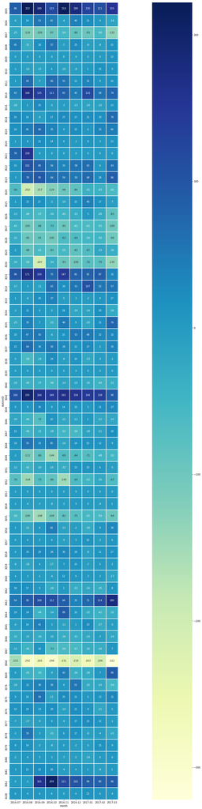

```python
#Draw a heatmap for the bikes net change of each station monthly
plt.figure(figsize=(50,60))
sns.heatmap(data_change2, cmap='YlGnBu', annot=True, fmt='d', square=True, linewidths=1);
```

For long-run pattern, we find that numbers of bikes in some stations kept increasing or decreasing at relatively high level.

Increasing station: 3005,3014,3022,3023,3031,3032,3042,3063,3082 Decreasing station: 3007,3024,3027,3028,3029,3030,3052,3055,3068

We recommend transport bikes monthly from increasing stations to decreasing stations according to our analysis. The specific strategy of transportation routes will be decided by the distance and exact change numbers.

### What is the breakdown of Trip Route Category-Passholder type combinations? What might make a particular combination more popular?

```python
#Get the numbers of trips for each type combinations
data_combin=data2021.groupby(['Trip Route Category', 'Passholder Type']).size().reset_index()
data_combin.columns=['Trip Route Category', 'Passholder Type','Number of trips']
data_combin
```

|  | Trip Route Category | Passholder Type | Number of trips |
| --- | --- | --- | --- |
| 0 | One Way | Flex Pass | 8974 |
| 1 | One Way | Monthly Pass | 77054 |
| 2 | One Way | Staff Annual | 230 |
| 3 | One Way | Walk-up | 32296 |
| 4 | Round Trip | Flex Pass | 483 |
| 5 | Round Trip | Monthly Pass | 3769 |
| 6 | Round Trip | Staff Annual | 83 |
| 7 | Round Trip | Walk-up | 8447 |

```python
data_combin2=data_combin.pivot_table(index='Passholder Type', columns='Trip Route Category', values='Number of trips')
data_combin2
```

| Trip Route Category Passholder Type | One Way | Round Trip |
| --- | --- | --- |
| Flex Pass | 8974 | 483 |
| Monthly Pass | 77054 | 3769 |
| Staff Annual | 230 | 83 |
| Walk-up | 32296 | 8447 |

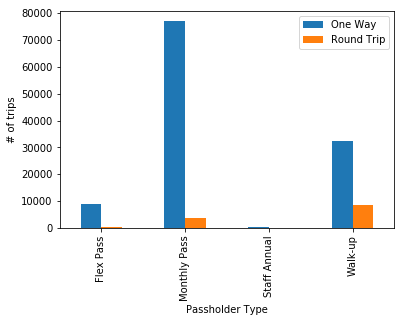

```python
plt.figure(figsize=(40,30))
data_combin2.plot(kind='bar')
plt.legend(loc='upper right')
plt.ylabel('# of trips')
plt.xlabel('Passholder Type')

plt.show()
```

From the figure we could find that one way trip is more popular among all kinds of passholder types than round trip.

People who most often ride one way trip are monthly pass memebers. They use bikes as their regualr ways to commute. They probably ride a one way trip to work or study and stay at that place for a long time, then ride another one way trip back home.

For round trips, it's more popular among walk-up groups than in other groups. That's may because walk-up people tend to only use bike occasionly, such as a short trip to pick up or buy something, or go sightseeing around. In this situation, they are more likely to come back to the same station to return bike. Another reason can be that they are not so familiar with different station locations, so going back to where they get it is the simplest way to return.